**Discrete Fourier Transformation (DFT)**

By Prof. Seungchul Lee  
http://iai.postech.ac.kr/  
Industrial AI Lab at POSTECH

Table of Contents

# 1. Fourier Series

## 1.1. Delta Dirac Function

$$ \sum_{n = 1,2,3,\cdots}\cos(n \theta) = \cos \theta + \cos 2\theta + \cos 3\theta + \cdots $$

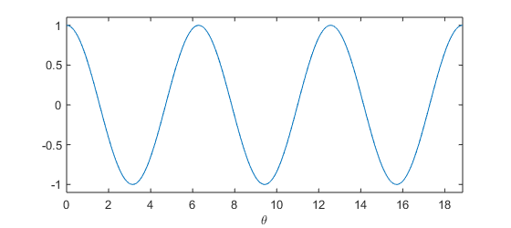

```matlab
%plot -s 560,250

theta = linspace(0,6*pi,2^8);
x1 = cos(theta);
plot(theta,x1), axis tight, ylim([-1.1 1.1]), xlabel('\theta')
```

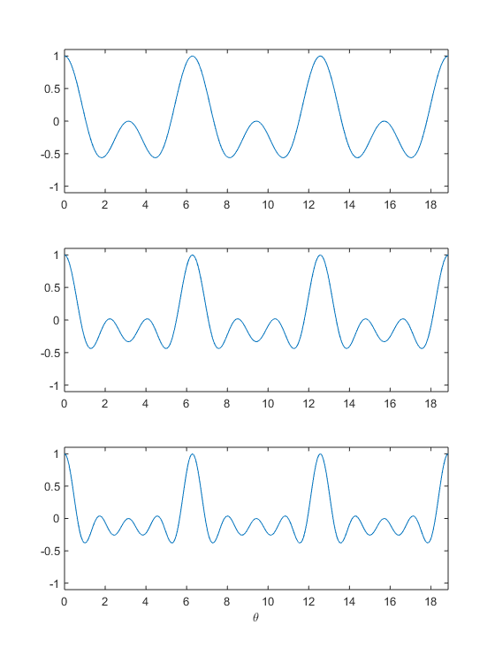

```matlab
%plot -s 560,750

x2 = x1 + cos(2*theta);
x3 = x2 + cos(3*theta);
x4 = x3 + cos(4*theta);
subplot(3,1,1), plot(theta, x2/2), axis tight, ylim([-1.1 1.1])
subplot(3,1,2), plot(theta, x3/3), axis tight, ylim([-1.1 1.1])
subplot(3,1,3), plot(theta, x4/4), axis tight, ylim([-1.1 1.1]), xlabel('\theta')
```

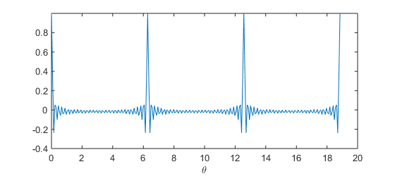

```matlab
%plot -s 560,250

x = zeros(1,2^8);

N = 30;
for n = 1:N
    x = x + cos(n*theta);
end

plot(theta,x/N), xlabel('\theta')
```

## 1.2. Square Wave

$$ \sum_{n = 1,3,5,\cdots}\frac{4}{\pi n} \sin (n\theta) = \frac{4}{\pi} \sin \theta + \frac{4}{3 \pi} \sin 3\theta + \frac{4}{5 \pi} \sin 5\theta + \cdots$$

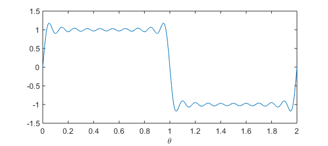

```matlab
%plot -s 560,250

N = 2^8;
x = zeros(1,N);
theta = linspace(0,2*pi,N);

for n = 1:2:20
    x = x + 4/(pi*n)*sin(n*theta);
end

plot(theta/pi,x), xlabel('\theta')
```

## 1.3. How to Decompose a Signal into Fundamental Harmonic Sinusoids

- DFT or FFT can do such a job !!!

[figure not shown]

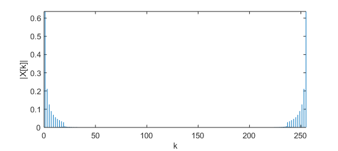

```matlab
%plot -s 560,250

xt = fft(x,N)/N;
stem(0:N-1,abs(xt),'marker','none'), axis tight, xlabel('k'), ylabel('|X[k]|')
```

$$ \sum_{n = 1,3,5,\cdots}\frac{4}{\pi n} \sin (n\theta) = \frac{4}{\pi} \sin \theta + \frac{4}{3 \pi} \sin 3\theta + \frac{4}{5 \pi} \sin 5\theta + \cdots$$

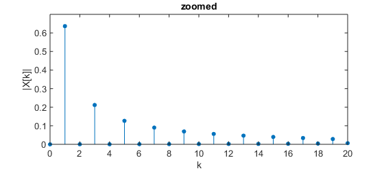

```matlab
%plot -s 560,250

stem(0:N-1,abs(xt),'filled','markersize',4), xlabel('k'), ylabel('|X[k]|'), title('zoomed')
xlim([0,20])
```

# 2. Signal Representation (optional)

## 2.1. Basis

A **basis** $\{b_k\}$ for a vector space $V$ is a collection of vectors from $V$ that linearly independent and span $V$

- Basis matrix: stack the basis vectors $b_k$ as columns

$$ B \,\,=\,\, \left[b_0 \mid b_1 \mid b_2 \mid \cdots \mid b_{N-1} \right]$$

- Using this matrix $B$, we can now write a linear combination of basis elements as the matrix/vector product

$$ \begin{align*} x & = \, B\, a\, =\, a_0 b_0 + a_1 b_1 +\, \cdots\, + a_{N-1} b_{N-1} \, =\, \sum_{k=0}^{N-1} a_k b_k \,\\ &=\, \left[b_0 \mid b_1 \mid b_2 \mid \cdots \mid b_{N-1} \right]\begin{bmatrix} a_0\\ a_1\\ \vdots\\ a_{N-1} \end{bmatrix} \end{align*}$$

### 2.1.1. Orthonormal Basis

- An **orthogonal basis** $\{b_k\}_{k=0}^{N-1}$ for a vector space $V$ is a basis whose elements are mutually orthogonal

$$\langle b_k,b_l\rangle \, =\, 0\, \quad k\, \neq\, l$$

- An **orthonormal basis**$\{b_k\}_{k=0}^{N-1}$ for a vector space $V$ is a basis whose elements are mutually orthogonal and normalized (in the 2-norm)

$$\begin{align*} \langle b_k,b_l\rangle \, &=\, 0\, \quad k\, \neq\, l, \quad \text{ and}\\ \| b_k\|_2 \, &= \, 1 \quad \forall k \end{align*}$$

- $B$ is a unitrary matrix

$$B^H B = I \implies B^{-1} = B^H, \qquad \text{where } B^H \text{ is complex conjugate transpose}$$

$$ \begin{align*} B^H B = \begin{bmatrix} b_0^H\\ b_1^H\\ \vdots\\ b_{N-1}^H \end{bmatrix} \left[b_0 \mid b_1 \mid b_2 \mid \cdots \mid b_{N-1} \right] \end{align*} = \begin{bmatrix} 1 & \\ & 1\\ & & \ddots\\ & & & 1 \end{bmatrix} $$

### 2.1.2. Signal Representation by Orthonormal Basis

Signal representation for any signal $x$

$$ \begin{align*} x &= B\alpha = \sum_{k=0}^{N-1}\alpha_kb_k, &\text{(synthesis)}\\ \\ \alpha &= B^Hx \qquad \text{or} \qquad \alpha_k = \langle x,b_k \rangle, &\text{(analysis)} \end{align*}$$

- **Synthesis**: Build up the signal $x$ as a linear combination of the basis elements $b_k$ weighted by the weights $\alpha_k$
- **Analysis**: Compute the weights $\alpha_k$ such that the synthesis produces $x$; the weight $\alpha_k$ measures the similarity between $x$ and the basis element $b_k$

## 2.2. Harmonic Sinusoids are an Orthonormal Basis

Stack $N$ normalized harmonic sinusoid $\{s_k\}_{k=0}^{N-1}$ as columns into an $N\times N$ complex orthonormal basis matrix

$$ \begin{align*} S = \left[s_0 \mid s_1 \mid \cdots \mid s_{N-1} \right] \quad \text{where}\quad s_k[n] = \frac{1}{\sqrt{N}}e^{j\frac{2\pi}{N}kn} \end{align*} $$

$$S^H S = I \implies \langle s_k,s_l\rangle \, =\, 0 \quad k\, \neq l,\quad \text{and}\quad \lVert s_k \rVert_2\, =\, 1$$

# 3. Discrete Fourier Tranformation (DFT)

**DFT**

- It finds the “frequency contents” at frequency $k$
- It measures the similarity between $x$ and the harmonic sinusoid $s_k$

$$ \begin{align*} X\, &=\, S^Hx \\ X[k]\, &=\, \langle x,s_k\rangle\, =\, \sum \limits_{n=0}^{N-1} x[n]\,\frac{e^{-j\frac{2 \pi}{N}kn}}{\sqrt{N}} \end{align*}$$

**Inverse DFT**

- It is returning to time domain
- It builds up the signal $x$ as a linear combination of $s_k$ weighted by the $X[k]$

$$ \begin{align*} x\, &=\, SX \\ x[n]\, &=\, \sum \limits_{k=0}^{N-1}X[k]\, \frac{e^{j\frac{2 \pi}{N}kn}}{\sqrt{N}} \end{align*} $$

**Unnormalized DFT**

- Normalized forward and inverse DFT

$$ \begin{align*}X[k] &= \sum \limits_{n=0}^{N-1} x[n]\,\frac{e^{-j\frac{2 \pi}{N}kn}}{\sqrt{N}}\\ x[n] &= \sum \limits_{k=0}^{N-1}X[k]\, \frac{e^{j\frac{2 \pi}{N}kn}}{\sqrt{N}} \end{align*} $$

- Unnormalized forward and inverse DFT

$$ \begin{align*}X_u[k] &= \sum \limits_{n=0}^{N-1} x[n]\,e^{-j\frac{2 \pi}{N}kn}\\ x[n] &= \frac{1}{N}\sum \limits_{k=0}^{N-1}X[k]\, e^{j\frac{2 \pi}{N}kn} \end{align*} $$

## 3.1. Fast Fourier Transformation (FFT)

- FFT algorithms are so commonly employed to compute DFT that the term 'FFT' is often used to mean 'DFT'
  - The FFT has been called the "most important computational algorithm of our generation"
  - It uses the dynamic programming algorithm (or divide and conquer) to efficiently compute DFT.
- DFT refers to a mathematical transformation or function, whereas 'FFT' refers to a specific family of algorithms for computing DFTs.
  - use `fft` command to compute `dft`
  - `fft` (computationally efficient)
- We will use the embedded `fft` function without going too much into detail.

[figure not shown]

**Example**

$$x[n] = e^{j\frac{2\pi}{8}n}$$

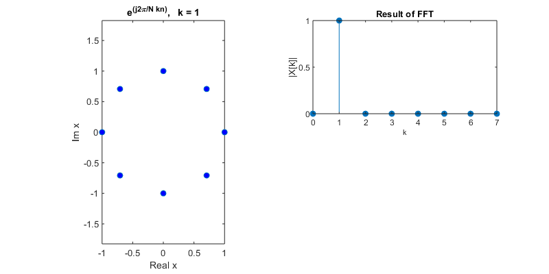

```matlab
%plot -s 800,400

k = 1;                      % index for freqeuncy

N = 8;
n = 0:N-1;                  % sampling period

x = exp(1j*2*pi/N*k*n);    % harmonic complex exponential
xt = fft(x)/N;

subplot(2,2,[1,3]), plot(real(x),imag(x),'o','MarkerFaceColor','b')
axis equal, xlabel('Real {x}'), ylabel('Im {x}')
title(['e^{(j2\pi/N kn)},   k = ',num2str(k)])

subplot(2,2,2), stem(n,abs(xt),'filled'), axis tight
xlabel('k','Fontsize',8), ylabel('|X[k]|')
title('Result of FFT')
```

$$x[n] = \cos \left(\frac{2\pi}{8}n \right)$$

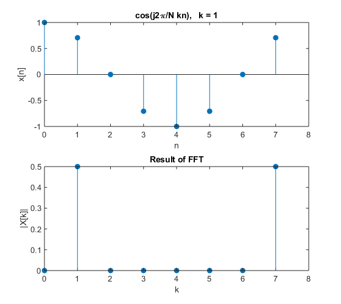

```matlab
%plot -s 560,500

k = 1;                        % index for freqeuncy

N = 8;
n = 0:N-1;                    % sampling period

x = cos(2*pi/N*k*n);          % harmonic complex exponential
xt = fft(x)/N;

subplot(2,1,1), stem(n,real(x),'filled'), xlim([0,8])
xlabel('n'), ylabel('x[n]')
title(['cos{(j2\pi/N kn)},   k = ',num2str(k)])

subplot(2,1,2); stem(n,abs(xt),'filled'), xlim([0,8])
xlabel('k'), ylabel('|X[k]|')
title('Result of FFT')
```

- Remember $$ \cos \omega t = \frac{e^{i \omega t} + e^{-i \omega t}}{2}$$

[figure not shown]

## 3.2. DFT Frequencies

- $X[k]$ measures the similarity between the time signal $x[n]$ and the harmonic sinusoid $s_k[n]$
- $X[k]$ measures the "frequency content" of $x[n]$ at frequency

$$\omega_k = \frac{2\pi}{N} k$$

- Typical interval 1: $0 \leq k \leq N-1$ corresponds to frequencies $\omega_k$ in the interval $0 \leq \omega \leq 2\pi$
- Typical interval 2: $-\frac{N}{2} \leq k \leq \frac{N}{2} -1$ corresponds to frequencies $\omega_k$ in the interval $-\pi \leq \omega \leq \pi$

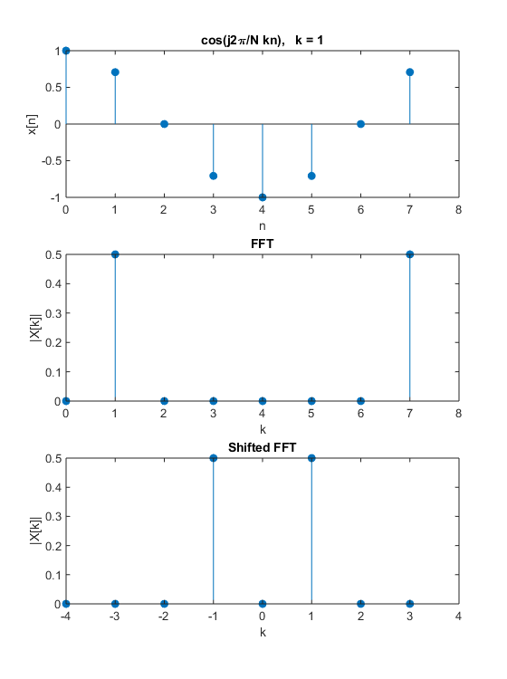

```matlab
%plot -s 560,750

k = 1;                        % index for freqeuncy

N = 8;
n = 0:N-1;                    % sampling period

x = cos(2*pi/N*k*n);          % harmonic complex exponential
xt = fft(x)/N;
xtshift = fftshift(xt);

kr = [0:N/2-1 -N/2:-1];
ks = fftshift(kr);

subplot(3,1,1), stem(n,real(x),'filled'), xlim([0,8])
xlabel('n'), ylabel('x[n]')
title(['cos{(j2\pi/N kn)},   k = ',num2str(k)])

subplot(3,1,2); stem(n,abs(xt),'filled'), xlim([0,8])
xlabel('k')
ylabel('|X[k]|')
title('FFT')

subplot(3,1,3); stem(ks,abs(xtshift),'filled'), xlim([-4,4])
xlabel('k')
ylabel('|X[k]|')
title('Shifted FFT')
```

[figure not shown]

# 4. Filtering in Frequency Domain

**DFT pair**

$$x[n] \longleftrightarrow X[k]$$

**DFT and Convolution**

- Convolution in the time domain $=$ multiplication in the frequency domain

$$ \begin{align*} Y[k] &= H[k]X[k] \\ h[n]\otimes x[n] &\longleftrightarrow H[k]X[k] \\ y[n] &= \text{IDFT}(Y[k]) \end{align*} $$

[figure not shown]

## 4.1. Filters

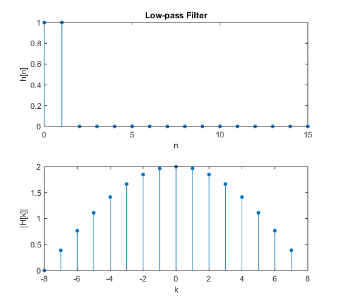

```matlab
%plot -s 560,500

%% low-pass filter
N = 16;
n = 0:N-1;

h = zeros(1,N);
h(1) = 1;
h(2) = 1;

kr = [0:N/2-1 -N/2:-1];
ks = fftshift(kr);

ht = fft(h,N);
htshift = fftshift(ht);

subplot(2,1,1),
stem(n,h,'filled','markersize',4), xlabel('n'), ylabel('h[n]'), title('Low-pass Filter')
subplot(2,1,2),
stem(ks,abs(htshift),'filled','markersize',4), xlabel('k'), ylabel('|H[k]|'), xlim([-N/2,N/2])
```

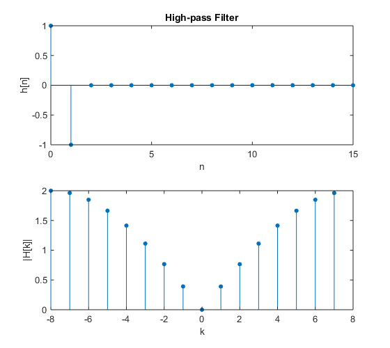

```matlab
%plot -s 560,500

%% high-pass filter
N = 16;
n = 0:N-1;

h = zeros(1,N);
h(1) = 1;
h(2) = -1;

kr = [0:N/2-1 -N/2:-1];
ks = fftshift(kr);

ht = fft(h,N);
htshift = fftshift(ht);

subplot(2,1,1),
stem(n,h,'filled','markersize',4), xlabel('n'), ylabel('h[n]'), title('High-pass Filter')
subplot(2,1,2),
stem(ks,abs(htshift),'filled','markersize',4), xlabel('k'), ylabel('|H[k]|'), xlim([-N/2,N/2])
```

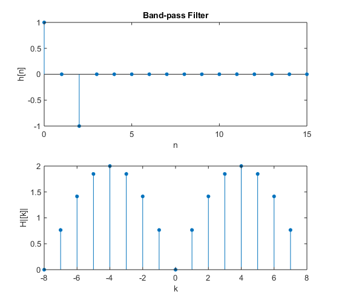

```matlab
%plot -s 560,500

%% band-pass filter
N = 16;
n = 0:N-1;

h = zeros(1,N);
h(1) = 1;
h(2) = 0;
h(3) = -1;

kr = [0:N/2-1 -N/2:-1];
ks = fftshift(kr);

ht = fft(h,N);
htshift = fftshift(ht);

subplot(2,1,1),
stem(n,h,'filled','markersize',4), xlabel('n'), ylabel('h[n]'), title('Band-pass Filter')
subplot(2,1,2),
stem(ks,abs(htshift),'filled','markersize',4), xlabel('k'), ylabel('H|[k]|'), xlim([-N/2,N/2])
```

## 4.2. FFT and Convolution

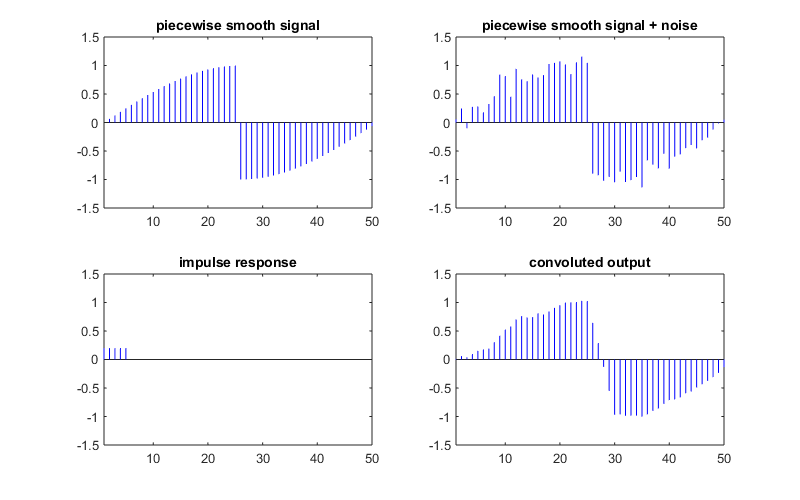

```matlab
%plot -s 800,500

% piecewise smooth signal
N = 50;
n = 0:N-1;

x = sin(pi/N*n)'.*[ones(N/2,1); -ones(N/2,1)];
xn = x + 0.1*randn(N,1);

% construct moving average filter impulse response of length M
M = 5;
h = zeros(N,1);
h(1:M) = 1/M;

% convolve noisy signal with impulse response
y = conv(xn,h);

subplot(2,2,1), stem(x,'b','Marker','none');
axis([1 N -1.5 1.5]), title('piecewise smooth signal')

subplot(2,2,2), stem(xn,'b','Marker','none');
axis([1 N -1.5 1.5]), title('piecewise smooth signal + noise')

subplot(2,2,3), stem(h,'b','Marker','none');
axis([1 N -1.5 1.5]), title('impulse response')

subplot(2,2,4), stem(y,'b','Marker','none'), xlim([1,N])
axis([1 N -1.5 1.5]), title('convoluted output')
```

$$ \begin{align*} Y[k] &= H[k]X[k] \\ h[n]\otimes x[n] &\longleftrightarrow H[k]X[k] \\ y[n] &= \text{IDFT}(Y[k]) \end{align*} $$

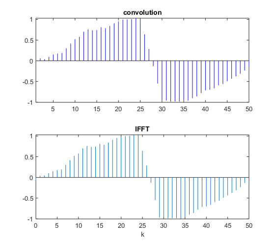

```matlab
%plot -s 560,500

k = 0:N-1;

ht = fft(h);
xnt = fft(xn);
xf = ifft(ht.*xnt);

subplot(2,1,1), stem(y,'b','Marker','none'), xlim([1,N]), title('convolution')
subplot(2,1,2), stem(k,xf,'marker','none'), title('IFFT'), xlabel('k')
```

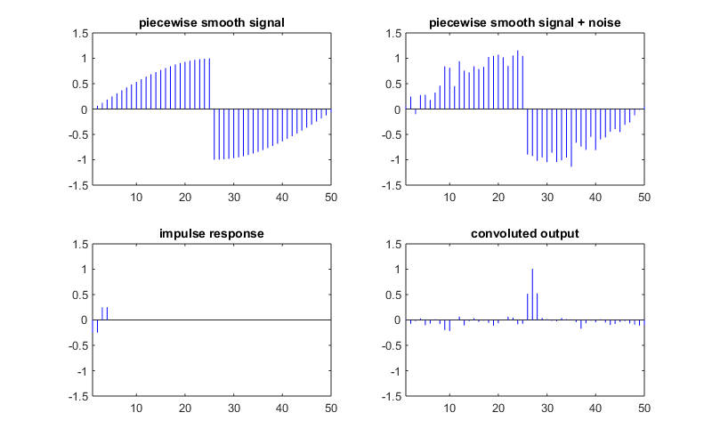

```matlab
%plot -s 800,500

% haar wavelet edge detector
M = 4;
h = zeros(N,1);
h(1:2) = -1/M;
h(3:4) = 1/M;

% convolve noisy signal with impulse response
y = conv(xn,h);

subplot(2,2,1), stem(x,'b','Marker','none');
axis([1 N -1.5 1.5]), title('piecewise smooth signal')

subplot(2,2,2), stem(xn,'b','Marker','none');
axis([1 N -1.5 1.5]), title('piecewise smooth signal + noise')

subplot(2,2,3), stem(h,'b','Marker','none');
axis([1 N -1.5 1.5]), title('impulse response')

subplot(2,2,4), stem(y,'b','Marker','none'), xlim([1,N])
axis([1 N -1.5 1.5]), title('convoluted output')
```

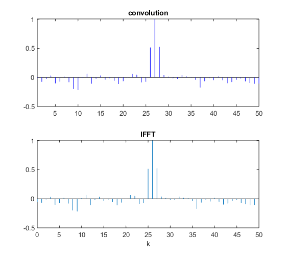

```matlab
%plot -s 560,500

k = 0:N-1;

ht = fft(h);
xnt = fft(xn);
xf = ifft(ht.*xnt);

subplot(2,1,1), stem(y,'b','Marker','none'), xlim([1,N]), title('convolution')
subplot(2,1,2), stem(k,xf,'marker','none'), title('IFFT'), xlabel('k')
```

```matlab
%%javascript
$.getScript('https://kmahelona.github.io/ipython_notebook_goodies/ipython_notebook_toc.js')
```